# Test a Perceptual Phenomenon

Read data from file.

```python
import os
import pandas

# The file path os.getcmd() return the current directory name we concat the file name at last.
# readcsv file and store in getdata_from_file variable.

getdata_from_file = pandas.read_csv(os.getcwd() + '\data\stroopdata.csv')

#To print all data present in this stroopdata.csv file.
getdata_from_file
```

|  | Congruent | Incongruent |
| --- | --- | --- |
| 0 | 12.079 | 19.278 |
| 1 | 16.791 | 18.741 |
| 2 | 9.564 | 21.214 |
| 3 | 8.630 | 15.687 |
| 4 | 14.669 | 22.803 |
| 5 | 12.238 | 20.878 |
| 6 | 14.692 | 24.572 |
| 7 | 8.987 | 17.394 |
| 8 | 9.401 | 20.762 |
| 9 | 14.480 | 26.282 |
| 10 | 22.328 | 24.524 |
| 11 | 15.298 | 18.644 |
| 12 | 15.073 | 17.510 |
| 13 | 16.929 | 20.330 |
| 14 | 18.200 | 35.255 |
| 15 | 12.130 | 22.158 |
| 16 | 18.495 | 25.139 |
| 17 | 10.639 | 20.429 |
| 18 | 11.344 | 17.425 |
| 19 | 12.369 | 34.288 |
| 20 | 12.944 | 23.894 |
| 21 | 14.233 | 17.960 |
| 22 | 19.710 | 22.058 |
| 23 | 16.004 | 21.157 |

```python
# Adding Subject column to stroopdata.csv file.
getdata_from_file['Subject'] = getdata_from_file.index + 1
```

```python
getdata_from_file
```

|  | Congruent | Incongruent | Subject |
| --- | --- | --- | --- |
| 0 | 12.079 | 19.278 | 1 |
| 1 | 16.791 | 18.741 | 2 |
| 2 | 9.564 | 21.214 | 3 |
| 3 | 8.630 | 15.687 | 4 |
| 4 | 14.669 | 22.803 | 5 |
| 5 | 12.238 | 20.878 | 6 |
| 6 | 14.692 | 24.572 | 7 |
| 7 | 8.987 | 17.394 | 8 |
| 8 | 9.401 | 20.762 | 9 |
| 9 | 14.480 | 26.282 | 10 |
| 10 | 22.328 | 24.524 | 11 |
| 11 | 15.298 | 18.644 | 12 |
| 12 | 15.073 | 17.510 | 13 |
| 13 | 16.929 | 20.330 | 14 |
| 14 | 18.200 | 35.255 | 15 |
| 15 | 12.130 | 22.158 | 16 |
| 16 | 18.495 | 25.139 | 17 |
| 17 | 10.639 | 20.429 | 18 |
| 18 | 11.344 | 17.425 | 19 |
| 19 | 12.369 | 34.288 | 20 |
| 20 | 12.944 | 23.894 | 21 |
| 21 | 14.233 | 17.960 | 22 |
| 22 | 19.710 | 22.058 | 23 |
| 23 | 16.004 | 21.157 | 24 |

**Question 1**: What is our independent variable? What is our dependent variable?

**Answer 1**: 1) Independent variable are Congruent and Incongruent. The variable do not change value based on other variable. 2) The variable change depending on other variable. Response Time in seconds.

**Question 2**: What is an appropriate set of hypotheses for this task? What kind of statistical test do you expect to perform? Justify your choices.

**Answer 2**: Null Hypothesis (μi - μc = 0). The pair follower a symmetric distribution around zero.(population mean of incongruent values - population mean of congruent values is Equal to 0).

Alternative Hypothesis: ( μi - μc ≠ 0 ). There is a significant difference, positive or negative, in the population average response times.

**Question 3**: Report some descriptive statistics regarding this dataset.Including at least one measure of centrality and one measure of variability.

```python
congruent = getdata_from_file["Congruent"]

incongruent = getdata_from_file["Incongruent"]
```

```python
congruent_mean = congruent.mean()

print("The Mean Value for Congruent is = " + str(congruent_mean))
```

```
The Mean Value for Congruent is = 14.051125000000004
```

```python
incongruent_mean = incongruent.mean()

print("The Mean Value for Incongruent is = " + str(incongruent_mean))
```

```
The Mean Value for Incongruent is = 22.01591666666667
```

```python
congruent_std = congruent.std()

print("The Standard deviation for Congruent is = " + str(congruent_std))
```

```
The Standard deviation for Congruent is = 3.559357957645195
```

```python
incongruent_median = congruent.median()

print("The Median value for Incongruent is = " + str(incongruent_median))
```

[output not shown]

**Question 4**: Plot the data one or two visualizations that show the distribution of the sample data. Write one or two sentences noting what you observe about the plot or plots.

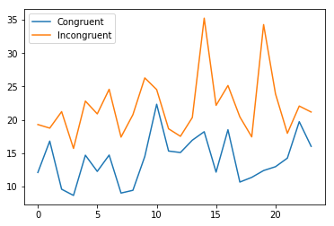

```python
import pandas as pd
import matplotlib.pyplot as plt
%matplotlib inline

file = pd.read_csv(os.getcwd() + '\data\stroopdata.csv')

plt.figure()

file.plot()
```

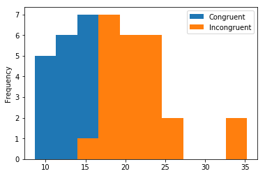

```python
file.plot(kind="hist")
```

**Question 5**: Now, perform the statistical test and report your results. What is your confidence level and your critical statistic value? Do you reject the null hypothesis or fail to reject it? Come to a conclusion in terms of the experiment task. Did the results match up with your expectations?

```python
from scipy import stats
from scipy.stats import t

t_statistic, p_value = stats.ttest_rel(a=getdata_from_file['Incongruent'],b=getdata_from_file['Congruent'])

print("t statistic = " + str(t_statistic))

print("p value = " + str(p_value))
```

```
t statistic = 8.020706944109957
p value = 4.103000585711178e-08
```

```python
# Number of subjects.

number_of_subject = getdata_from_file["Subject"]

print("Number of Subject = " + str(len(number_of_subject)))
```

```
Number of Subject = 24
```

```python
# t-critical value for a 99% confidence level.
print("t-critical value for a 99% confidence level = " + str(t.ppf(.99,23)))
```

```
t-critical value for a 99% confidence level = 2.4998667394943976
```

**Question 6**: Optional: What do you think is responsible for the effects observed? Can you think of an alternative or similar task that would result in a similar effect? Some research about the problem will be helpful for thinking about these two questions!

I think this effect is caused by the distraction resulted from the presence of the words and particularly, the wrongly labled words.The most common theory for Stroop effect is called interference.It makes brain shower.Confucius the brain the brain reads word first instead of font color.

#### References

https://en.wikipedia.org/wiki/Stroop_effect

http://reu.dimacs.rutgers.edu/Symbols.pdf

https://www.youtube.com/watch?v=rdFz3yvZfdQ

http://pandas.pydata.org/pandas-docs/stable/visualization.html#visualization

https://www.youtube.com/watch?v=KLnGOL_AUgA

https://docs.scipy.org/doc/scipy/reference/tutorial/stats.html

https://www.youtube.com/watch?v=_Qlxt0HmuOo

https://www.youtube.com/watch?v=VK-rnA3-41c

https://www.youtube.com/watch?v=_Qlxt0HmuOo

http://pandas.pydata.org/pandas-docs/stable/visualization.html#visualization